```python
import warnings
warnings.filterwarnings('ignore')
import numpy as np
import pandas as pd
import seaborn as sns
import matplotlib.pyplot as plt
import scipy
import scipy.stats as stats
from scipy.stats import kurtosis
from scipy.stats import ttest_ind
from matplotlib import pyplot as plt
from statsmodels.stats.outliers_influence import variance_inflation_factor
```

```python
from IPython.display import HTML

HTML('''
<script src='//code.jquery.com/jquery-3.3.1.min.js'></script>
<script>
code_show=true;
function code_toggle() {
if (code_show){
$('div.input').hide();
$('div .jp-CodeCell .jp-Cell-inputWrapper').hide();
} else {
$('div.input').show();
$('div .jp-CodeCell .jp-Cell-inputWrapper').show();
}
code_show = !code_show
}
$( document ).ready(code_toggle);
</script>
<form action="javascript:code_toggle()"><input type="submit" value="Code on/off"></form>''')
```

# DATA PREVIEW ON WATER QUALITY

### Drinking water potability

### NOTES

The following analysis are based on the open-sources data: https://www.kaggle.com/adityakadiwal/water-potability

## ABSTRACT

Access to safe drinking-water is essential to health, a basic human right and a component of effective policy for health protection. This is important as a health and development issue at a national, regional and local level. In some regions, it has been shown that investments in water supply and sanitation can yield a net economic benefit, since the reductions in adverse health effects and health care costs outweigh the costs of undertaking the interventions.

## FEATRUES

#### 2. Hardness

Hardness is mainly caused by calcium and magnesium salts. These salts are dissolved from geologic deposits through which water travels. The length of time water is in contact with hardness producing material helps determine how much hardness there is in raw water. Hardness was originally defined as the capacity of water to precipitate soap caused by Calcium and Magnesium.

#### 3. Solids (Total dissolved solids - TDS)

Water has the ability to dissolve a wide range of inorganic and some organic minerals or salts such as potassium, calcium, sodium, bicarbonates, chlorides, magnesium, sulfates etc. These minerals produced un-wanted taste and diluted color in appearance of water. This is the important parameter for the use of water. The water with high TDS value indicates that water is highly mineralized. Desirable limit for TDS is 500 mg/l and maximum limit is 1000 mg/l which prescribed for drinking purpose.

#### 4. Chloramines

Chlorine and chloramine are the major disinfectants used in public water systems. Chloramines are most commonly formed when ammonia is added to chlorine to treat drinking water. Chlorine levels up to 4 milligrams per liter (mg/L or 4 parts per million (ppm)) are considered safe in drinking water.

#### 5. Sulfate

Sulfates are naturally occurring substances that are found in minerals, soil, and rocks. They are present in ambient air, groundwater, plants, and food. The principal commercial use of sulfate is in the chemical industry. Sulfate concentration in seawater is about 2,700 milligrams per liter (mg/L). It ranges from 3 to 30 mg/L in most freshwater supplies, although much higher concentrations (1000 mg/L) are found in some geographic locations.

#### 6. Conductivity

Pure water is not a good conductor of electric current rather’s a good insulator. Increase in ions concentration enhances the electrical conductivity of water. Generally, the amount of dissolved solids in water determines the electrical conductivity. Electrical conductivity (EC) actually measures the ionic process of a solution that enables it to transmit current. According to WHO standards, EC value should not exceeded 400 μS/cm.

#### 7. Organic_carbon

Total Organic Carbon (TOC) in source waters comes from decaying natural organic matter (NOM) as well as synthetic sources. TOC is a measure of the total amount of carbon in organic compounds in pure water. According to US EPA < 2 mg/L as TOC in treated / drinking water, and < 4 mg/Lit in source water which is use for treatment.

#### 8. Trihalomethanes

THMs are chemicals which may be found in water treated with chlorine. The concentration of THMs in drinking water varies according to the level of organic material in the water, the amount of chlorine required to treat the water, and the temperature of the water that is being treated. THM levels up to 80 ppm is considered safe in drinking water.

#### 9. Turbidity

The turbidity of water depends on the quantity of solid matter present in the suspended state. It is a measure of light emitting properties of water and the test is used to indicate the quality of waste discharge with respect to colloidal matter. The mean turbidity value obtained for Wondo Genet Campus (0.98 NTU) is lower than the WHO recommended value of 5.00 NTU.

#### 10. Potability (Predicted Variable)

Indicates if water is safe for human consumption where 1 means Potable and 0 means Not potable.

## COLUMN DESCRIPTION

$ppm$: parts per million  
$μg/L$: microgram per litre  
$mg/L$: milligram per litre

- **ph**: pH of water (0 to 14).
- **Hardness**: Capacity of water to precipitate soap in mg/L.
- **Solids**: Total dissolved solids in ppm.
- **Chloramines**: Amount of Chloramines in ppm.
- **Sulfate**: Amount of Sulfates dissolved in mg/L.
- **Conductivity**: Electrical conductivity of water in μS/cm.
- **Organic_carbon**: Amount of organic carbon in ppm.
- **Trihalomethanes**: Amount of Trihalomethanes in μg/L.
- **Turbidity**: Measure of light emiting property of water in NTU.
- **Potability**: Indicates if water is safe for human consumption. Potable -1 and Not potable -0.

```python
# PATH TO FILE
path = "path/"
path_water_potability = path + 'Water Potability.csv'
```

```python
# LOAD IN DATA
water_potability_org = pd.read_csv(path_water_potability)
```

```python
# DROP DUPLICATE RECORDS
drop_dup = water_potability_org.drop_duplicates(subset = None, keep = 'first', inplace = False)
```

```python
# DETECT OUTLIERS
def detect_outlier_z_score(col):
    outliers = []
    for x in col:
        z_score = (x - np.mean(col))/np.std(col)
        if np.abs(z_score) > 3: outliers.append(x)  # 6-sigma for 99.99966%
    num_outlier = len(outliers)
    return num_outlier

def detect_outlier_IQR(col):
    outliers = []
    sorted(col)
    Q1, Q3 = np.nanpercentile(col,[25,75])
    lower_range = Q1 - (1.5* (Q3 - Q1))
    upper_range = Q3 + (1.5* (Q3 - Q1))
    for x in col:
        if x > upper_range or x < lower_range: outliers.append(x)
    num_outlier = len(outliers)
    return num_outlier

# DETECT MULTICOLLINEARITY
def calc_vif(X):
    vif = pd.DataFrame()
    vif["variables"] = X.columns
    vif["VIF"] = [variance_inflation_factor(X.values, i) for i in range(X.shape[1])]
    return(vif)
```

## DATA PREVIEW

### 1. Overview of the orginal data

```python
# CHECK EACH COLUMN
add = [(drop_dup.columns[i],
        len(drop_dup.iloc[:,i]),
        drop_dup.iloc[:,i].isnull().sum(),
        len(drop_dup.iloc[:,i]) - drop_dup.iloc[:,i].isnull().sum(),
        detect_outlier_z_score(drop_dup.iloc[:,i]),
        detect_outlier_IQR(drop_dup.iloc[:,i]),
        np.nanmean(drop_dup.iloc[:,i]),
        np.nanmedian(drop_dup.iloc[:,i]),
        np.nanstd(drop_dup.iloc[:,i]),
        drop_dup.iloc[:,i].skew(axis = 0, skipna = True),
        kurtosis(drop_dup.iloc[:,i], fisher = True))
       for i in range(len(drop_dup.columns))]
water_count_org = pd.DataFrame(add,
                               columns = ['Variable', 'Number of Rows', 'Number of Missing', 'Number of Effective Rows',
                                          'Number of Outliers (Z-score)', 'Number of Outliers (IQR)',
                                          'Mean', 'Median', 'Standard Deviation', 'Skewness', 'Kurtosis'])
water_count_org
```

|  | Variable | Number of Rows | Number of Missing | Number of Effective Rows | Number of Outliers (Z-score) | Number of Outliers (IQR) | Mean | Median | Standard Deviation | Skewness | Kurtosis |
| --- | --- | --- | --- | --- | --- | --- | --- | --- | --- | --- | --- |
| 0 | PH | 3276 | 491 | 2785 | 16 | 46 | 7.080795 | 7.036752 | 1.594033 | 0.025630 | NaN |
| 1 | Hardness | 3276 | 0 | 3276 | 18 | 83 | 196.369496 | 196.967627 | 32.874743 | -0.039342 | 0.613001 |
| 2 | Solids | 3276 | 0 | 3276 | 20 | 47 | 22014.092526 | 20927.833605 | 8767.232421 | 0.621634 | 0.440320 |
| 3 | Chloramines | 3276 | 0 | 3276 | 20 | 61 | 7.122277 | 7.130299 | 1.582843 | -0.012098 | 0.587170 |
| 4 | Sulfate | 3276 | 781 | 2495 | 17 | 41 | 333.775777 | 333.073546 | 41.408540 | -0.035947 | NaN |
| 5 | Conductivity | 3276 | 0 | 3276 | 7 | 11 | 426.205111 | 421.884968 | 80.811727 | 0.264490 | -0.278501 |
| 6 | Organic_carbon | 3276 | 0 | 3276 | 4 | 25 | 14.284970 | 14.218338 | 3.307657 | 0.025533 | 0.042511 |
| 7 | Trihalomethanes | 3276 | 162 | 3114 | 12 | 33 | 66.396293 | 66.622485 | 16.172411 | -0.083031 | NaN |
| 8 | Turbidity | 3276 | 0 | 3276 | 9 | 19 | 3.966786 | 3.955028 | 0.780263 | -0.007817 | -0.064536 |
| 9 | Potability | 3276 | 0 | 3276 | 0 | 0 | 0.390110 | 0.000000 | 0.487775 | 0.450784 | -1.796980 |

```python
water = drop_dup
# DROP ROWS WITH MISSING IN POTABILITY COLUMN
water = water.dropna(axis = 0, how = 'any', thresh = None, subset = ['Potability'], inplace = False)
```

### 2. Overview of the imputed data

Since the distributions are approximately normal with Means and Medians closed to each other for each variables, thus imputed the missing values by the means of each columns. We are not supposed to delete the missing values before imputation since the number of missingness are significantly large.

Here attached the imputed data.

```python
# IMPUTE MISSING

for i in range(len(water.columns)):
    condition = water.iloc[:,i].isnull()
    ind = water.index[condition]
    water.iloc[ind, i] = np.nanmean(water.iloc[:,i])

add = [(water.columns[i],
        len(water.iloc[:,i]),
        water.iloc[:,i].isnull().sum(),
        len(water.iloc[:,i]) - water.iloc[:,i].isnull().sum(),
        detect_outlier_z_score(water.iloc[:,i]),
        detect_outlier_IQR(water.iloc[:,i]),
        np.nanmean(water.iloc[:,i]),
        np.nanmedian(water.iloc[:,i]),
        np.nanstd(water.iloc[:,i]),
        water.iloc[:,i].skew(axis = 0, skipna = True),
        kurtosis(water.iloc[:,i], fisher = True))
       for i in range(len(water.columns))]
water_count_imputed = pd.DataFrame(add,
                                   columns = ['Variable', 'Number of Rows', 'Number of Missing', 'Number of Effective Rows',
                                              'Number of Outliers (Z-score)', 'Number of Outliers (IQR)',
                                              'Mean', 'Median', 'Standard Deviation', 'Skewness', 'Kurtosis'])
water_count_imputed
```

|  | Variable | Number of Rows | Number of Missing | Number of Effective Rows | Number of Outliers (Z-score) | Number of Outliers (IQR) | Mean | Median | Standard Deviation | Skewness | Kurtosis |
| --- | --- | --- | --- | --- | --- | --- | --- | --- | --- | --- | --- |
| 0 | PH | 3276 | 0 | 3276 | 28 | 142 | 7.080795 | 7.080795 | 1.469732 | 0.027796 | 1.372159 |
| 1 | Hardness | 3276 | 0 | 3276 | 18 | 83 | 196.369496 | 196.967627 | 32.874743 | -0.039342 | 0.613001 |
| 2 | Solids | 3276 | 0 | 3276 | 20 | 47 | 22014.092526 | 20927.833605 | 8767.232421 | 0.621634 | 0.440320 |
| 3 | Chloramines | 3276 | 0 | 3276 | 20 | 61 | 7.122277 | 7.130299 | 1.582843 | -0.012098 | 0.587170 |
| 4 | Sulfate | 3276 | 0 | 3276 | 34 | 264 | 333.775777 | 333.775777 | 36.137095 | -0.041184 | 1.785403 |
| 5 | Conductivity | 3276 | 0 | 3276 | 7 | 11 | 426.205111 | 421.884968 | 80.811727 | 0.264490 | -0.278501 |
| 6 | Organic_carbon | 3276 | 0 | 3276 | 4 | 25 | 14.284970 | 14.218338 | 3.307657 | 0.025533 | 0.042511 |
| 7 | Trihalomethanes | 3276 | 0 | 3276 | 18 | 54 | 66.396293 | 66.396293 | 15.767474 | -0.085161 | 0.404650 |
| 8 | Turbidity | 3276 | 0 | 3276 | 9 | 19 | 3.966786 | 3.955028 | 0.780263 | -0.007817 | -0.064536 |
| 9 | Potability | 3276 | 0 | 3276 | 0 | 0 | 0.390110 | 0.000000 | 0.487775 | 0.450784 | -1.796980 |

### 3. Outliers

The final data is as below.

```python
# DELETE OUTLIERS

outliers_ind = []
for j in range(len(water.columns)):
    col = water.iloc[:,j]
    nanmean_col = np.nanmean(col)
    nanstd_col = np.nanstd(col)
    for i in range(len(col)):
        x = water.iloc[i,j]
        z_score = (x - nanmean_col)/nanstd_col
        if np.abs(z_score) > 3:
            outliers_ind.append(i)
water = water.drop(outliers_ind, axis = 0, inplace = False)

add = [(water.columns[i],
        len(water.iloc[:,i]),
        water.iloc[:,i].isnull().sum(),
        len(water.iloc[:,i]) - water.iloc[:,i].isnull().sum(),
        detect_outlier_z_score(water.iloc[:,i]),
        detect_outlier_IQR(water.iloc[:,i]),
        np.nanmean(water.iloc[:,i]),
        np.nanmedian(water.iloc[:,i]),
        np.nanstd(water.iloc[:,i]),
        water.iloc[:,i].skew(axis = 0, skipna = True),
        kurtosis(water.iloc[:,i], fisher = True))
       for i in range(len(water.columns))]
water_count_del = pd.DataFrame(add,
                               columns = ['Variable', 'Number of Rows', 'Number of Missing', 'Number of Effective Rows',
                                          'Number of Outliers (Z-score)', 'Number of Outliers (IQR)',
                                          'Mean', 'Median', 'Standard Deviation', 'Skewness', 'Kurtosis'])
water_count_del
```

|  | Variable | Number of Rows | Number of Missing | Number of Effective Rows | Number of Outliers (Z-score) | Number of Outliers (IQR) | Mean | Median | Standard Deviation | Skewness | Kurtosis |
| --- | --- | --- | --- | --- | --- | --- | --- | --- | --- | --- | --- |
| 0 | PH | 3128 | 0 | 3128 | 10 | 129 | 7.080681 | 7.080795 | 1.369704 | 0.073993 | 0.475700 |
| 1 | Hardness | 3128 | 0 | 3128 | 4 | 66 | 196.308606 | 196.967627 | 31.539816 | -0.048818 | 0.215774 |
| 2 | Solids | 3128 | 0 | 3128 | 8 | 31 | 21788.450883 | 20860.182045 | 8358.201847 | 0.470682 | -0.060493 |
| 3 | Chloramines | 3128 | 0 | 3128 | 8 | 42 | 7.108753 | 7.123789 | 1.515172 | -0.062213 | 0.111160 |
| 4 | Sulfate | 3128 | 0 | 3128 | 16 | 238 | 334.124593 | 333.775777 | 33.650049 | 0.080843 | 0.849865 |
| 5 | Conductivity | 3128 | 0 | 3128 | 0 | 4 | 425.834192 | 421.474794 | 80.293729 | 0.224300 | -0.432417 |
| 6 | Organic_carbon | 3128 | 0 | 3128 | 1 | 22 | 14.300105 | 14.243397 | 3.284380 | -0.013610 | -0.105012 |
| 7 | Trihalomethanes | 3128 | 0 | 3128 | 2 | 36 | 66.427270 | 66.396293 | 15.410338 | -0.024941 | 0.066536 |
| 8 | Turbidity | 3128 | 0 | 3128 | 1 | 11 | 3.964477 | 3.951949 | 0.768285 | -0.030712 | -0.189137 |
| 9 | Potability | 3128 | 0 | 3128 | 0 | 0 | 0.382992 | 0.000000 | 0.486116 | 0.481629 | -1.768256 |

### 4. Check Distributions

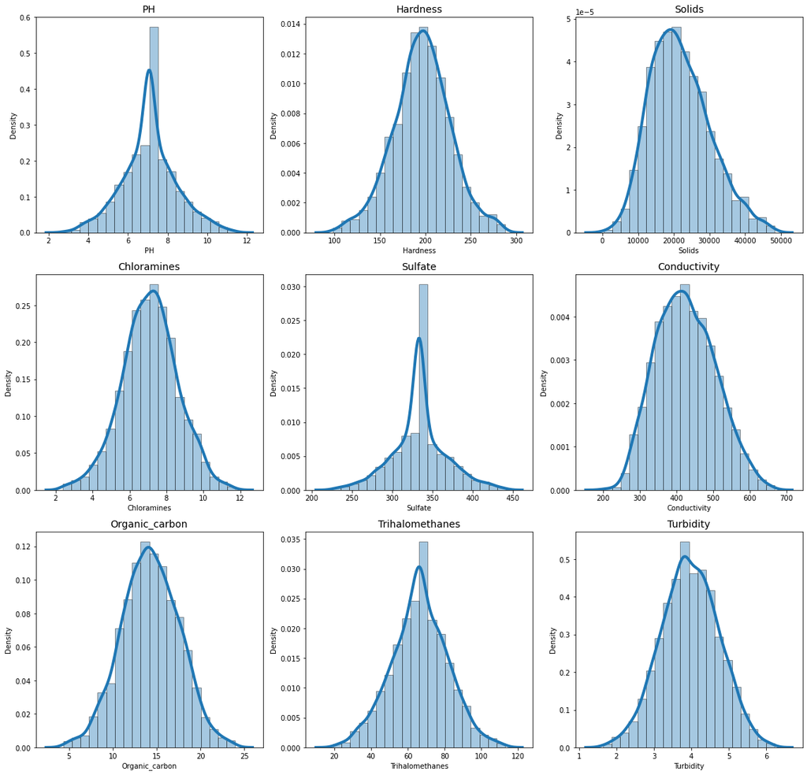

```python
# CHECK DISTRIBUTION
def compare(data, name, fig, rows, cols):         # FUNCTION TO DISPLAY SEVERAL HISTOGRAMS (ONLINE)
    for i in range(len(data.columns[:-1])):       # DISTRIBUTION NOT VALID TO CATEGORICAL VARIABLE
        plt.figure(figsize = (10,5))              # SET THE FIGURE SIZE
        plt.figure(fig)
        plt.subplot(rows, cols, i + 1)            # 3 x 3 MATRIX
        sns.distplot(data.iloc[:,i], hist = True, kde = True, bins = 20,
                     hist_kws = {'edgecolor':'black'}, kde_kws={'linewidth': 4})  # PLOT HISTOGRAMS WITH NUMBER OF BINS = 20
        plt.title(name[i], fontsize = 14)
    return

plt.figure(figsize = (16,20))
compare(water, water.columns, 1, 4, 3)
plt.tight_layout()                                # INCREASE THE SPACE BETWEEN PLOTS
plt.show()
```

Note that all variables are approximately normally distributed according to both chart and figures.

### 5. Check Correlations

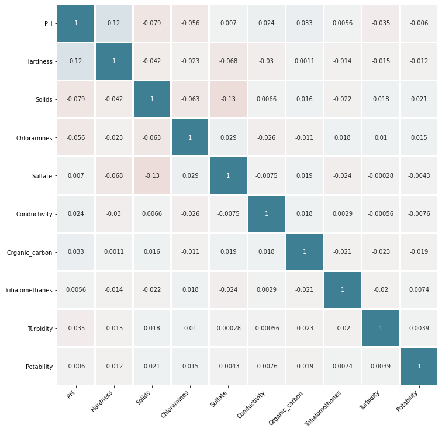

```python
# CHECK CORRELATION
plt.figure(figsize = (12, 12))
corr = water.corr()
ax = sns.heatmap(corr, vmin = -1, vmax = 1, center = 0,
                 cmap = sns.diverging_palette(20, 220, n = 200), linewidths = 2,
                 square = True, annot = True, fmt='.2g',
                 cbar_kws= {'orientation': 'vertical'},
                 cbar = False)
ax.set_xticklabels(
    ax.get_xticklabels(),
    rotation = 45,
    horizontalalignment = 'right');
```

Note that these is no significant relationships between each pairs.

### 6. Check Multicollinearity

```python
# DETECT MULTICOLLINEARITY
calc_vif(water.iloc[:,:-1])
```

|  | variables | VIF |
| --- | --- | --- |
| 0 | PH | 26.382088 |
| 1 | Hardness | 34.360948 |
| 2 | Solids | 7.427377 |
| 3 | Chloramines | 21.265164 |
| 4 | Sulfate | 63.744816 |
| 5 | Conductivity | 26.383213 |
| 6 | Organic_carbon | 18.953499 |
| 7 | Trihalomethanes | 18.166340 |
| 8 | Turbidity | 25.025665 |

**Attention**: High Multicollinearity

**Tips**: A key goal of regression analysis is to isolate the relationship between each independent variable and the dependent variable. The interpretation of a regression coefficient is that it represents the mean change in the dependent variable for each 1 unit change in an independent variable when you hold all of the other independent variables constant. That last portion is crucial for our discussion about multicollinearity.

The idea is that you can change the value of one independent variable and not the others. However, when independent variables are correlated, it indicates that changes in one variable are associated with shifts in another variable. The stronger the correlation, the more difficult it is to change one variable without changing another. It becomes difficult for the model to estimate the relationship between each independent variable and the dependent variable independently because the independent variables tend to change in unison.

**Multicollinearity causes the following two basic types of problems**:

1. The coefficient estimates can swing wildly based on which other independent variables are in the model. The coefficients become very sensitive to small changes in the model.
2. Multicollinearity reduces the precision of the estimated coefficients, which weakens the statistical power of your regression model. You might not be able to trust the p-values to identify independent variables that are statistically significant.

### 7. Overlook of "Potable" and "Not Potable"

```python
pot = water[water['Potability'] == 1]
not_pot = water[water['Potability'] == 0]
```

#### (1) Proportions

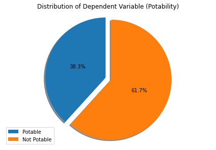

```python
sizes = [len(pot), len(not_pot)]

# CREATE PLOT
fig1, ax1 = plt.subplots()
patches, texts, autotexts = ax1.pie(sizes, explode = (0, 0.1), labels = None,
                                    autopct='%1.1f%%', pctdistance = 0.5,
                                    shadow = True, startangle=90)
# ADJUST TEXTS
for text in texts:
    text.set_color('black')
for autotext in autotexts:
    autotext.set_color('black')

# SHOW PLOT
ax1.axis('equal')
plt.tight_layout()
plt.legend(['Potable','Not Potable'])
plt.title("Distribution of Dependent Variable (Potability)")
plt.show()
```

#### (2) Distributions

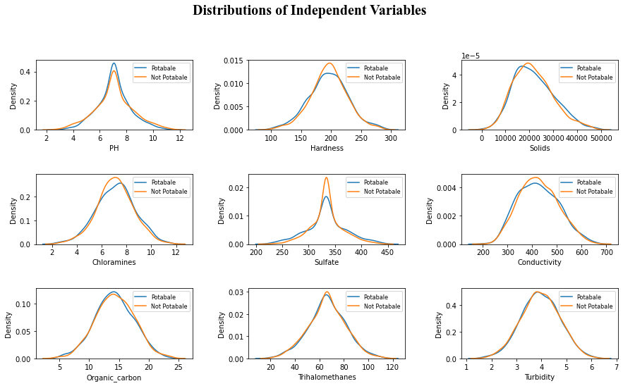

```python
for i, col in enumerate(water.columns[:-1]):
    plt.figure(figsize = (13,8))
    plt.figure(1)
    plt.subplot(3,3,i+1)

    sns.kdeplot(x = pot[col], label = 'Potabale')
    sns.kdeplot(x = not_pot[col], label = 'Not Potabale')
    plt.legend(prop = dict(size = 8))

plt.suptitle('Distributions of Independent Variables', fontname = "Times New Roman", fontsize = 20, fontweight = "bold")
plt.tight_layout(pad = 3.0)
plt.show()
```

#### (3) Boxplots

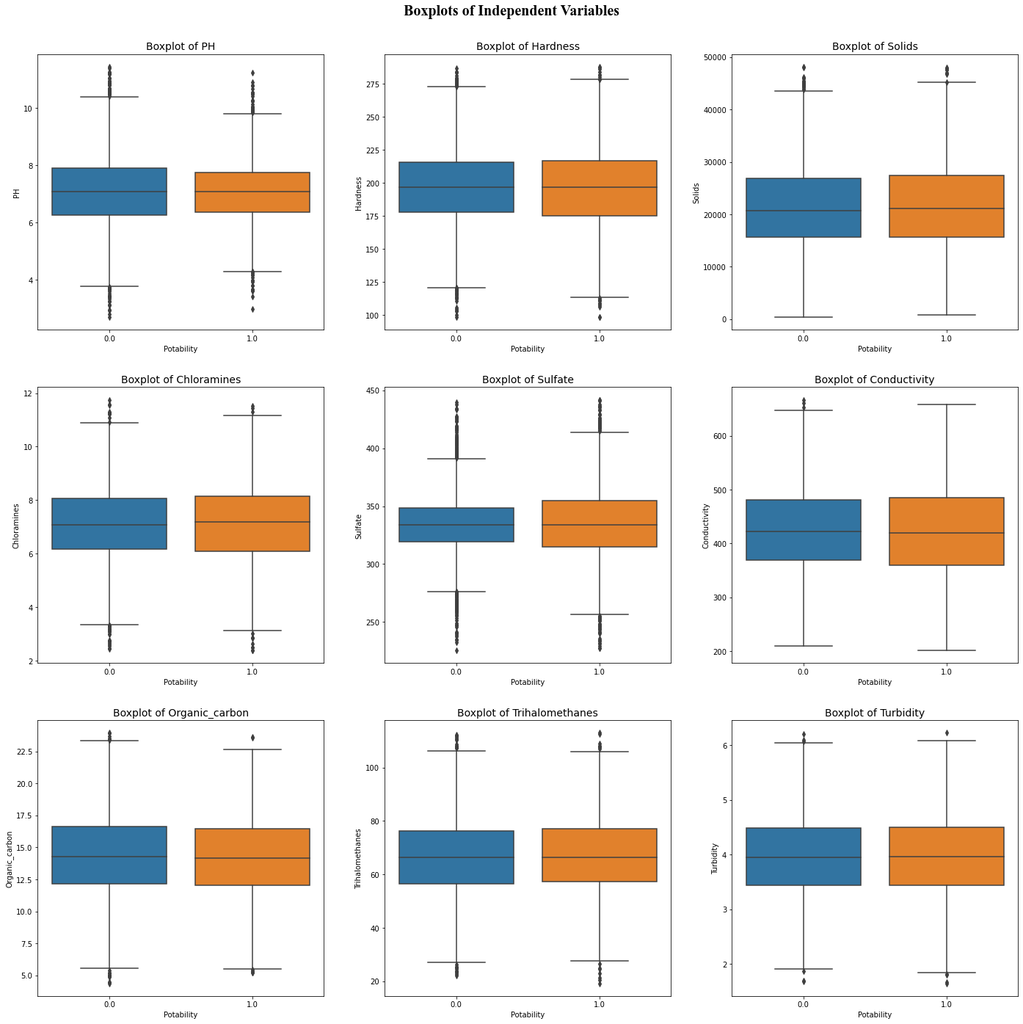

```python
for i in range(len(water.columns[:-1])):
    plt.figure(figsize = (20,20))
    plt.figure(1)
    plt.subplot(3,3,i+1)

    sns.boxplot(x = water["Potability"], y = water.iloc[:,i])
    plt.title(f'Boxplot of '+ water.columns[i], fontsize = 14)

plt.suptitle('Boxplots of Independent Variables', fontname = "Times New Roman", fontsize = 20, fontweight = "bold")
plt.tight_layout(pad = 3.0)
plt.show()
```

#### (4) T-tests

```python
add = [scipy.stats.ttest_ind(pot[col], not_pot[col], axis = 0, equal_var = True) for col in water.columns[:-1]]
stats = pd.DataFrame(add, columns = ['T-Statistics', 'P-Value'])
stats.index = water.columns[:-1]
stats
```

|  | T-Statistics | P-Value |
| --- | --- | --- |
| PH | -0.332809 | 0.739301 |
| Hardness | -0.650833 | 0.515202 |
| Solids | 1.165859 | 0.243760 |
| Chloramines | 0.861627 | 0.388959 |
| Sulfate | -0.237709 | 0.812122 |
| Conductivity | -0.422365 | 0.672787 |
| Organic_carbon | -1.045335 | 0.295949 |
| Trihalomethanes | 0.412311 | 0.680140 |
| Turbidity | 0.215389 | 0.829478 |

None of the p-values are significant at any reasonable alpha level. Redo the cleaning step if necessary.